# Respirometry Plotting and Analysis

AS Huffmyer

2021

This script analyzes and plots data for Symbiotic Integration 2021 respirometry data.

# **Setup**

Set up workspace, set options, and load required packages.

```r
knitr::opts_chunk$set(echo = TRUE, warning = FALSE, message = FALSE)
```

```r
## install packages if you dont already have them in your library
if ("tidyverse" %in% rownames(installed.packages()) == 'FALSE') install.packages('tidyverse')
if ("car" %in% rownames(installed.packages()) == 'FALSE') install.packages('car')
if ("lme4" %in% rownames(installed.packages()) == 'FALSE') install.packages('lme4')
if ("lmerTest" %in% rownames(installed.packages()) == 'FALSE') install.packages('lmerTest')
if ("scales" %in% rownames(installed.packages()) == 'FALSE') install.packages('scales')
if ("cowplot" %in% rownames(installed.packages()) == 'FALSE') install.packages('cowplot')
if ("ggplot2" %in% rownames(installed.packages()) == 'FALSE') install.packages('ggplot2')
if ("effects" %in% rownames(installed.packages()) == 'FALSE') install.packages('effects')
if ("emmeans" %in% rownames(installed.packages()) == 'FALSE') install.packages('emmeans')
if ("multcomp" %in% rownames(installed.packages()) == 'FALSE') install.packages('multcomp')

#load packages
library("ggplot2")
library("tidyverse")
library('car')
library('lme4')
library('lmerTest')
library('scales')
library('cowplot')
library('effects')
library('emmeans')
library('multcomp')
```

# **Data visualization and manipulation**

Load data from LoLinR.

```r
PRdata<-read.csv("Mcap2021/Output/Respiration/oxygen_P_R_calc.csv") #load data
```

Separate project specific data.

```r
#remove all rows of wells that did not have samples or blanks
PRdata<-PRdata[!is.na(PRdata$Type),]

#format columns
PRdata$Temperature<-as.factor(PRdata$Temperature)
PRdata$Plate<-as.factor(PRdata$Plate)
PRdata$Run<-as.factor(PRdata$Run)
```

Calculate a P:R ratio using gross photosynthesis.

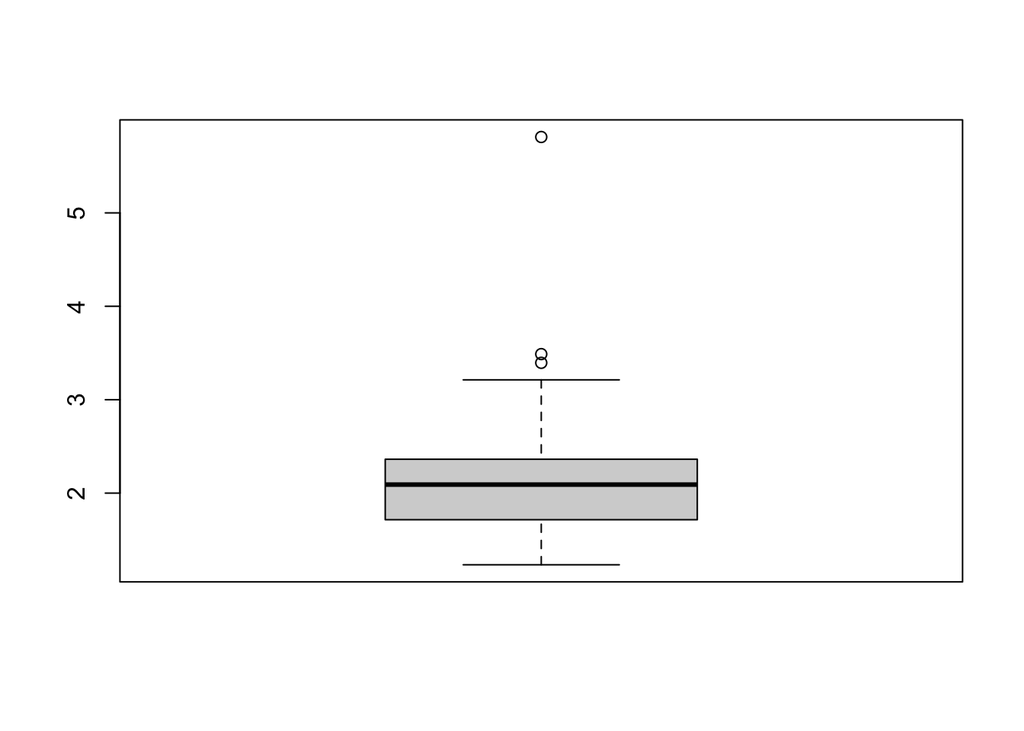

```r
PRdata$ratio<-abs(PRdata$GP.nmol.org.min)/abs(PRdata$R.nmol.org.min) #calculate ratio with absolute values
#remove outliers detected by values of P:R ratio data
boxplot(PRdata$ratio)
```

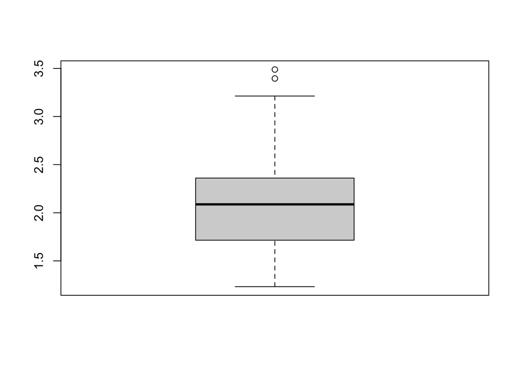

```r
PRdata<-PRdata%>%filter(ratio < 5)
boxplot(PRdata$ratio)
```

Look for outliers in the data.

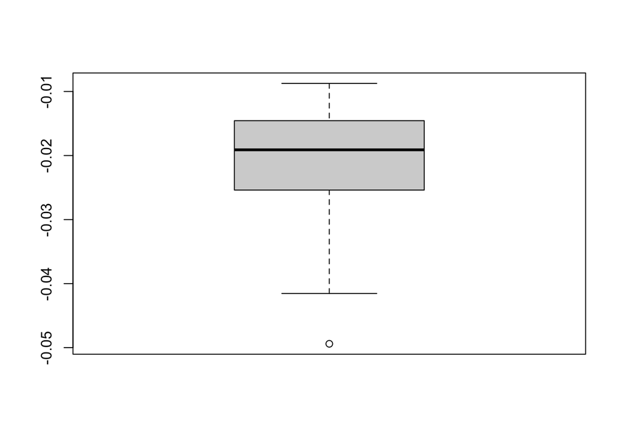

```r
boxplot(PRdata$R.nmol.org.min)
```

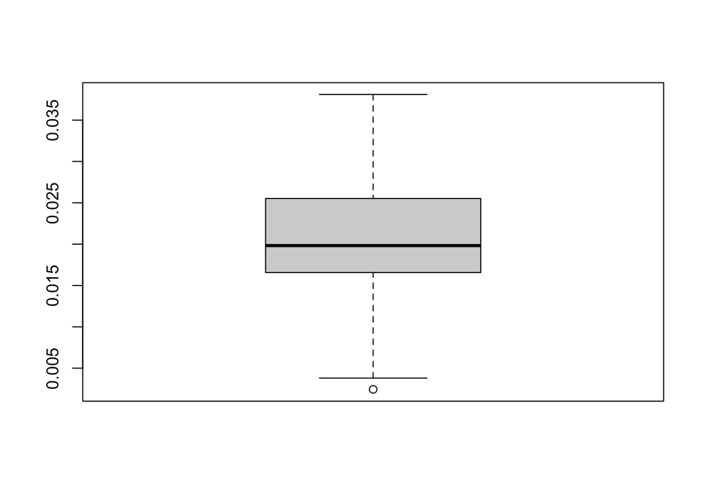

```r
#PRdata<-PRdata%>%filter(R.nmol.org.min < 10)
#boxplot(PRdata$R.nmol.org.min)

boxplot(PRdata$P.nmol.org.min)
```

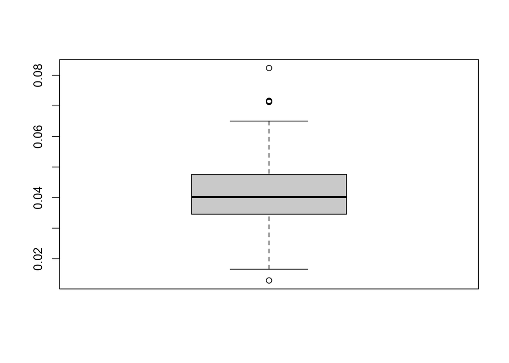

```r
#PRdata<-PRdata%>%filter(P.nmol.org.min < 10)
#boxplot(PRdata$P.nmol.org.min)

boxplot(PRdata$GP.nmol.org.min)
```

```r
#PRdata<-PRdata%>%filter(GP.nmol.org.min < 10)
#boxplot(PRdata$GP.nmol.org.min)
```

No apparent outliers in the data.

# **Plotting**

## Respiration

Plot data as an interaction plot

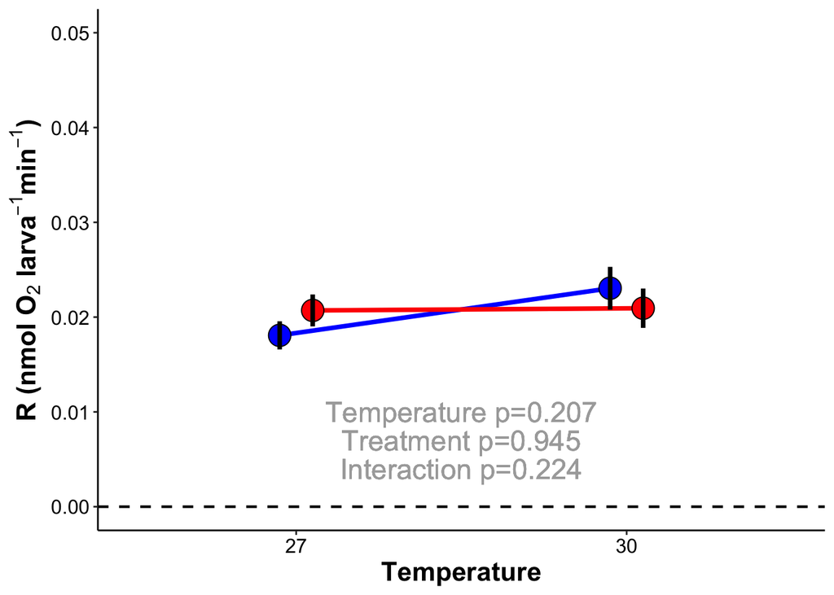

```r
r_plot<-PRdata %>%
    group_by(Treatment, Temperature)%>%
    dplyr::summarise(mean=mean(abs(R.nmol.org.min)), sd=sd(abs(R.nmol.org.min)), N=length(R.nmol.org.min), se=sd/sqrt(N))%>%
    ggplot(., aes(x = as.factor(Temperature), y = abs(mean), group=interaction(Treatment, Temperature))) +
    geom_hline(yintercept=0, linetype="dashed", color="black", size=0.75)+
    geom_line(position=position_dodge(0.2), size=1.3, aes(color=Treatment, group=Treatment)) +
    geom_point(aes(fill=Treatment, group=interaction(Treatment, Temperature)), pch = 21, size=6, position = position_dodge(0.2)) +
    geom_errorbar(aes(ymin=mean-se, ymax=mean+se, group=interaction(Treatment, Temperature)), width=0, linetype="solid", position=position_dodge(0.2), size=1.3, color="black")+
    xlab("Temperature") +
    scale_fill_manual(name="Rearing Treatment", values=c("blue","red"))+
    scale_color_manual(name="Rearing Treatment", values=c("blue","red"))+
    ylab(expression(bold(paste("R (nmol ", O[2], " larva"^-1, "min"^-1, ")")))) +
    #scale_y_continuous(limits=c(0.5, -0.005), labels = scales::number_format(accuracy = 0.01, decimal.mark = '.'))+
    ylim(0, 0.05)+
    geom_text(x=1.5, y=0.007, label="Treatment p=0.945", color="darkgray", size=6)+
    geom_text(x=1.5, y=0.01, label="Temperature p=0.207", color="darkgray", size=6)+
    geom_text(x=1.5, y=0.004, label="Interaction p=0.224", color="darkgray", size=6)+
    theme_classic() +
    theme(
      legend.position="none",
      axis.title=element_text(face="bold", size=16),
      axis.text=element_text(size=12, color="black"),
      legend.title=element_text(face="bold", size=14),
      legend.text=element_text(size=12)
      ); r_plot
```

```r
#ggsave("Mcap2021/Figures/Respiration/Respiration.png", r_plot, dpi=300, w=5, h=5, units="in")
```

Plot data as a box plot

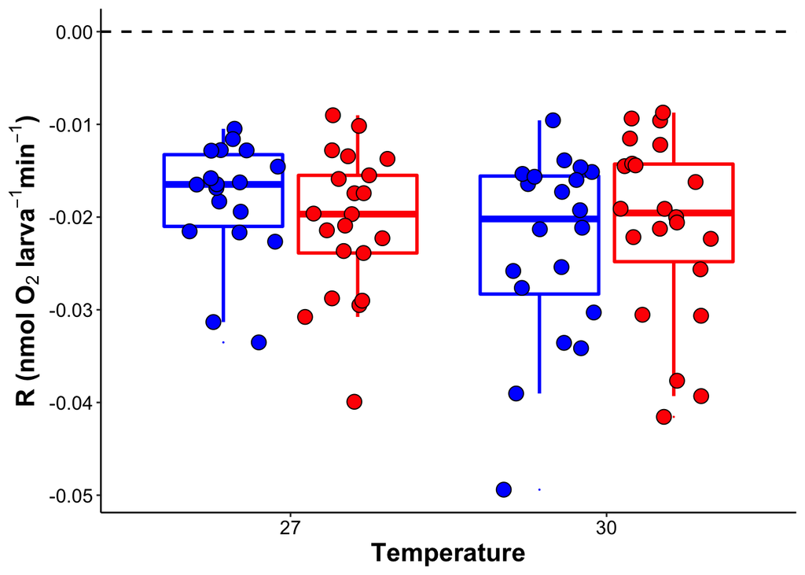

```r
r_plot_2<-PRdata %>%
    group_by(Treatment, Temperature)%>%
    ggplot(., aes(x = as.factor(Temperature), y = R.nmol.org.min, group=interaction(Treatment, Temperature))) +
    geom_hline(yintercept=0, linetype="dashed", color="black", size=0.75)+
    geom_boxplot(aes(color=Treatment, group=interaction(Treatment, Temperature)), outlier.size = 0, position = position_dodge(0.85), lwd=1) +
    geom_point(aes(fill=Treatment, group=interaction(Treatment, Temperature)), pch = 21, size=4, position = position_jitterdodge(0.3)) +
    xlab("Temperature") +
    scale_fill_manual(name="Rearing Treatment", values=c("blue","red"))+
    scale_color_manual(name="Rearing Treatment", values=c("blue","red"))+
    ylab(expression(bold(paste("R (nmol ", O[2], " larva"^-1, "min"^-1, ")")))) +
    #scale_y_continuous(limits=c(-0.03, 0.005), labels = scales::number_format(accuracy = 0.01, decimal.mark = '.'))+
    theme_classic() +
    theme(
      legend.position="none",
      axis.title=element_text(face="bold", size=16),
      axis.text=element_text(size=12, color="black"),
      legend.title=element_text(face="bold", size=14),
      legend.text=element_text(size=12)
      ); r_plot_2
```

```r
#ggsave("Mcap2021/Figures/Respiration/Respiration_box.png", r_plot_2, dpi=300, w=5, h=5, units="in")
```

## Photosynthesis (Net)

Plot data as an interaction plot

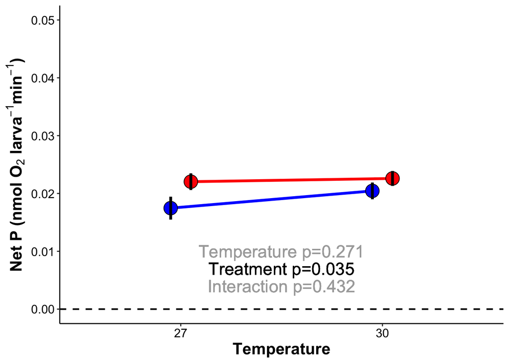

```r
p_plot<-PRdata %>%
    dplyr::group_by(Treatment, Temperature)%>%
    dplyr::summarise(mean=mean(P.nmol.org.min), sd=sd(P.nmol.org.min), N=length(P.nmol.org.min), se=sd/sqrt(N))%>%
    ggplot(., aes(x = as.factor(Temperature), y = mean, group=interaction(Treatment, Temperature))) +
    geom_hline(yintercept=0, linetype="dashed", color="black", size=0.75)+
    geom_line(position=position_dodge(0.2), size=1.3, aes(color=Treatment, group=Treatment)) +
    geom_point(aes(fill=Treatment, group=interaction(Treatment, Temperature)), pch = 21, size=6, position = position_dodge(0.2)) +
    geom_errorbar(aes(ymin=mean-se, ymax=mean+se, group=interaction(Treatment, Temperature)), width=0, linetype="solid", position=position_dodge(0.2), size=1.3, color="black")+
    xlab("Temperature") +
    scale_fill_manual(name="Rearing Treatment", values=c("blue","red"))+
    scale_color_manual(name="Rearing Treatment", values=c("blue","red"))+
    ylab(expression(bold(paste("Net P (nmol ", O[2], " larva"^-1, "min"^-1, ")")))) +
    geom_text(x=1.5, y=0.007, label="Treatment p=0.035", color="black", size=6)+
    geom_text(x=1.5, y=0.01, label="Temperature p=0.271", color="darkgray", size=6)+
    geom_text(x=1.5, y=0.004, label="Interaction p=0.432", color="darkgray", size=6)+
    ylim(0, 0.05) +
    theme_classic() +
    theme(
      legend.position="none",
      axis.title=element_text(face="bold", size=16),
      axis.text=element_text(size=12, color="black"),
      legend.title=element_text(face="bold", size=14),
      legend.text=element_text(size=12)
      ); p_plot
```

Plot data as a box plot

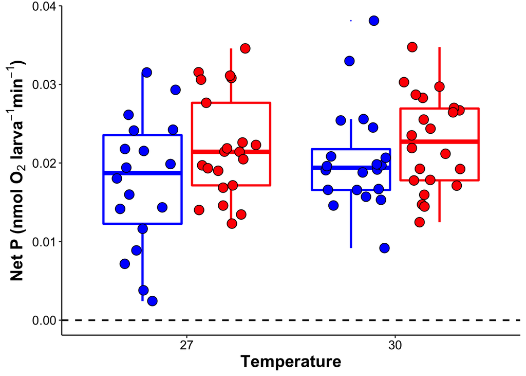

```r
p_plot_2<-PRdata %>%
    group_by(Treatment, Temperature)%>%
    ggplot(., aes(x = as.factor(Temperature), y = P.nmol.org.min, group=interaction(Treatment, Temperature))) +
    geom_hline(yintercept=0, linetype="dashed", color="black", size=0.75)+
    geom_boxplot(aes(color=Treatment, group=interaction(Treatment, Temperature)), outlier.size = 0, position = position_dodge(0.85), lwd=1) +
    geom_point(aes(fill=Treatment, group=interaction(Treatment, Temperature)), pch = 21, size=4, position = position_jitterdodge(0.3)) +
    xlab("Temperature") +
    scale_fill_manual(name="Rearing Treatment", values=c("blue","red"))+
    scale_color_manual(name="Rearing Treatment", values=c("blue","red"))+
    ylab(expression(bold(paste("Net P (nmol ", O[2], " larva"^-1, "min"^-1, ")")))) +
    #scale_y_continuous(limits=c(-0.03, 0.005), labels = scales::number_format(accuracy = 0.01, decimal.mark = '.'))+
    theme_classic() +
    theme(
      legend.position="none",
      axis.title=element_text(face="bold", size=16),
      axis.text=element_text(size=12, color="black"),
      legend.title=element_text(face="bold", size=14),
      legend.text=element_text(size=12)
      ); p_plot_2
```

```r
#ggsave("Mcap2021/Figures/Respiration/NetPhotosynthesis_box.png", p_plot_2, dpi=300, w=5, h=5, units="in")
```

## Photosynthesis (Gross)

Plot data as an interaction plot

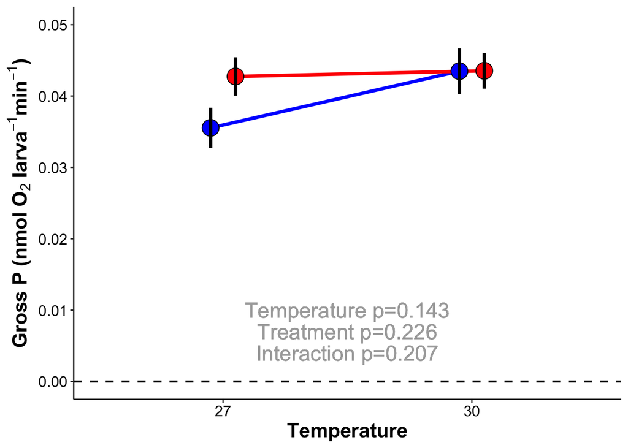

```r
gp_plot<-PRdata %>%
    dplyr::group_by(Treatment, Temperature)%>%
    dplyr::summarise(mean=mean(GP.nmol.org.min), sd=sd(GP.nmol.org.min), N=length(GP.nmol.org.min), se=sd/sqrt(N))%>%
    ggplot(., aes(x = as.factor(Temperature), y = mean, group=interaction(Treatment, Temperature))) +
    geom_hline(yintercept=0, linetype="dashed", color="black", size=0.75)+
    geom_line(position=position_dodge(0.2), size=1.3, aes(color=Treatment, group=Treatment)) +
    geom_point(aes(fill=Treatment, group=interaction(Treatment, Temperature)), pch = 21, size=6, position = position_dodge(0.2)) +
    geom_errorbar(aes(ymin=mean-se, ymax=mean+se, group=interaction(Treatment, Temperature)), width=0, linetype="solid", position=position_dodge(0.2), size=1.3, color="black")+
    xlab("Temperature") +
    scale_fill_manual(name="Rearing Treatment", values=c("blue","red"))+
    scale_color_manual(name="Rearing Treatment", values=c("blue","red"))+
    ylab(expression(bold(paste("Gross P (nmol ", O[2], " larva"^-1, "min"^-1, ")")))) +
    ylim(0, 0.05) +
    geom_text(x=1.5, y=0.007, label="Treatment p=0.226", color="darkgray", size=6)+
    geom_text(x=1.5, y=0.01, label="Temperature p=0.143", color="darkgray", size=6)+
    geom_text(x=1.5, y=0.004, label="Interaction p=0.207", color="darkgray", size=6)+
    theme_classic() +
    theme(
      legend.position="none",
      axis.title=element_text(face="bold", size=16),
      axis.text=element_text(size=12, color="black"),
      legend.title=element_text(face="bold", size=14),
      legend.text=element_text(size=12)
      ); gp_plot
```

Plot data as a box plot

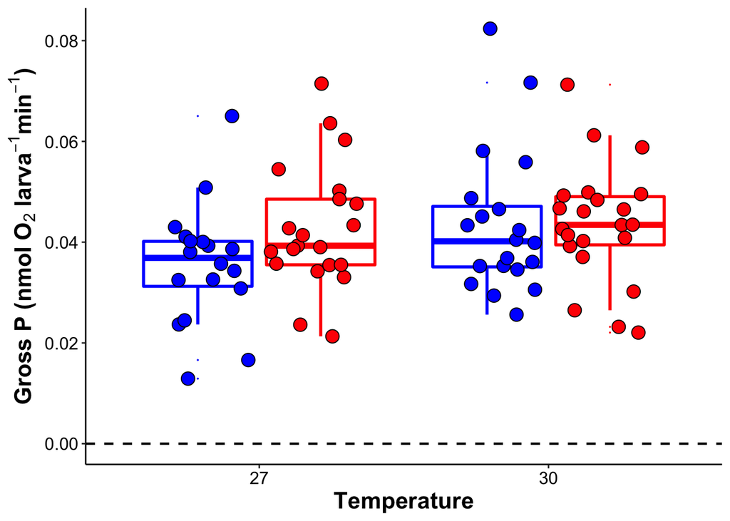

```r
gp_plot_2<-PRdata %>%
    group_by(Treatment, Temperature)%>%
    ggplot(., aes(x = as.factor(Temperature), y = GP.nmol.org.min, group=interaction(Treatment, Temperature))) +
    geom_hline(yintercept=0, linetype="dashed", color="black", size=0.75)+
    geom_boxplot(aes(color=Treatment, group=interaction(Treatment, Temperature)), outlier.size = 0, position = position_dodge(0.85), lwd=1) +
    geom_point(aes(fill=Treatment, group=interaction(Treatment, Temperature)), pch = 21, size=4, position = position_jitterdodge(0.3)) +
    xlab("Temperature") +
    scale_fill_manual(name="Rearing Treatment", values=c("blue","red"))+
    scale_color_manual(name="Rearing Treatment", values=c("blue","red"))+
    ylab(expression(bold(paste("Gross P (nmol ", O[2], " larva"^-1, "min"^-1, ")")))) +
    #scale_y_continuous(limits=c(-0.03, 0.005), labels = scales::number_format(accuracy = 0.01, decimal.mark = '.'))+
    theme_classic() +
    theme(
      legend.position="none",
      axis.title=element_text(face="bold", size=16),
      axis.text=element_text(size=12, color="black"),
      legend.title=element_text(face="bold", size=14),
      legend.text=element_text(size=12)
      ); gp_plot_2
```

```r
#ggsave("Mcap2021/Figures/Respiration/GrossPhotosynthesis_box.png", gp_plot_2, dpi=300, w=5, h=5, units="in")
```

## P:R Ratio

Plot data as an interaction plot

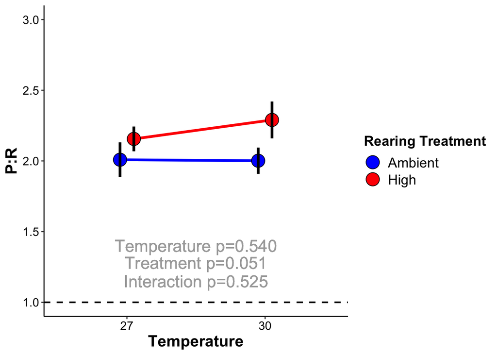

```r
pr_plot<-PRdata %>%
    dplyr::group_by(Treatment, Temperature)%>%
    dplyr::summarise(mean=mean(ratio), sd=sd(ratio), N=length(ratio), se=sd/sqrt(N))%>%
    ggplot(., aes(x = as.factor(Temperature), y = mean, group=interaction(Treatment, Temperature))) +
    geom_hline(yintercept=1, linetype="dashed", color="black", size=0.75)+
    geom_line(position=position_dodge(0.2), size=1.3, aes(color=Treatment, group=Treatment)) +
    geom_point(aes(fill=Treatment, group=interaction(Treatment, Temperature)), pch = 21, size=6, position = position_dodge(0.2)) +
    geom_errorbar(aes(ymin=mean-se, ymax=mean+se, group=interaction(Treatment, Temperature)), width=0, linetype="solid", position=position_dodge(0.2), size=1.3, color="black")+
    xlab("Temperature") +
    scale_fill_manual(name="Rearing Treatment", values=c("blue","red"))+
    scale_color_manual(name="Rearing Treatment", values=c("blue","red"))+
    ylab(expression(bold(paste("P:R")))) +
    #scale_y_continuous(limits=c(0.8, 3), labels = scales::number_format(accuracy = 0.01, decimal.mark = '.'))+
    ylim(1, 3) +
    geom_text(x=1.5, y=1.28, label="Treatment p=0.051", color="darkgray", size=6)+
    geom_text(x=1.5, y=1.4, label="Temperature p=0.540", color="darkgray", size=6)+
    geom_text(x=1.5, y=1.15, label="Interaction p=0.525", color="darkgray", size=6)+
    theme_classic() +
    theme(
      legend.position="right",
      axis.title=element_text(face="bold", size=16),
      axis.text=element_text(size=12, color="black"),
      legend.title=element_text(face="bold", size=14),
      legend.text=element_text(size=14)
      ); pr_plot
```

Plot data as a box plot

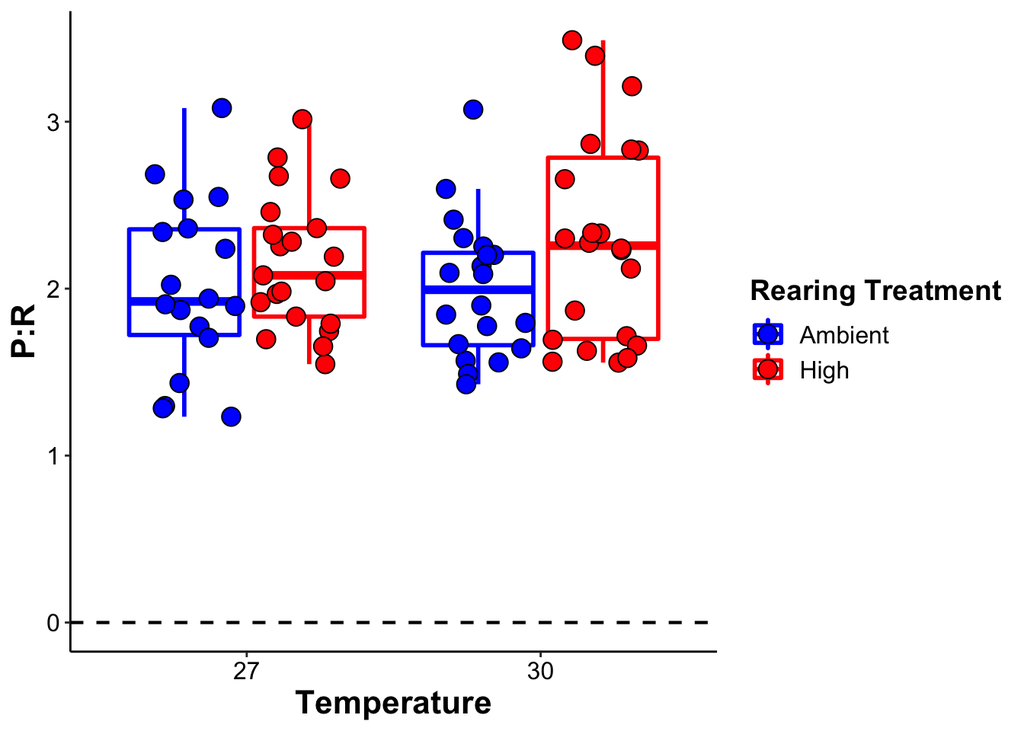

```r
pr_plot_2<-PRdata %>%
    group_by(Treatment, Temperature)%>%
    ggplot(., aes(x = as.factor(Temperature), y = ratio, group=interaction(Treatment, Temperature))) +
    geom_hline(yintercept=0, linetype="dashed", color="black", size=0.75)+
    geom_boxplot(aes(color=Treatment, group=interaction(Treatment, Temperature)), outlier.size = 0, position = position_dodge(0.85), lwd=1) +
    geom_point(aes(fill=Treatment, group=interaction(Treatment, Temperature)), pch = 21, size=4, position = position_jitterdodge(0.3)) +
    xlab("Temperature") +
    scale_fill_manual(name="Rearing Treatment", values=c("blue","red"))+
    scale_color_manual(name="Rearing Treatment", values=c("blue","red"))+
    ylab(expression(bold(paste("P:R")))) +
    #scale_y_continuous(limits=c(-0.03, 0.005), labels = scales::number_format(accuracy = 0.01, decimal.mark = '.'))+
    theme_classic() +
    theme(
      legend.position="right",
      axis.title=element_text(face="bold", size=16),
      axis.text=element_text(size=12, color="black"),
      legend.title=element_text(face="bold", size=14),
      legend.text=element_text(size=12)
      ); pr_plot_2
```

```r
#ggsave("Mcap2021/Figures/Respiration/PRratio_box.png", pr_plot_2, dpi=300, w=5, h=5, units="in")
```

## Generate final figure

```r
full_fig<-plot_grid(r_plot, p_plot, gp_plot, pr_plot, ncol=4, nrow=1, rel_heights= c(1,1,1,1), rel_widths = c(1,1,1,1.4), label_y=1, align="h")

ggsave(filename="Mcap2021/Figures/Respiration/respirometry_fig.png", plot=full_fig, dpi=500, width=18, height=6, units="in")
```

```r
full_fig_box<-plot_grid(r_plot_2, p_plot_2, gp_plot_2, pr_plot_2, ncol=4, nrow=1, rel_heights= c(1,1,1,1), rel_widths = c(1,1,1,1.4), label_y=1, align="h")

ggsave(filename="Mcap2021/Figures/Respiration/respirometry_fig_box.png", plot=full_fig_box, dpi=500, width=18, height=6, units="in")
```

# **Analyze data**

## Respiration

Build linear mixed effect model and examine for Respiration.

```r
Rmodel1<-lmer(R.nmol.org.min~Treatment*Temperature + (1|Run) + (1|Tank), data=PRdata) #run as random
anova(Rmodel1, type="II")
```

```
## Type II Analysis of Variance Table with Satterthwaite's method
##                           Sum Sq    Mean Sq NumDF  DenDF F value Pr(>F)
## Treatment             3.0000e-08 3.0000e-08     1  9.346  0.0005 0.9832
## Temperature           2.4519e-05 2.4519e-05     1  2.027  0.3798 0.5998
## Treatment:Temperature 1.1424e-04 1.1424e-04     1 65.630  1.7694 0.1881
```

```r
summary(Rmodel1)
```

```
## Linear mixed model fit by REML. t-tests use Satterthwaite's method [
## lmerModLmerTest]
## Formula: R.nmol.org.min ~ Treatment * Temperature + (1 | Run) + (1 | Tank)
##    Data: PRdata
##
## REML criterion at convergence: -505.6
##
## Scaled residuals:
##     Min      1Q  Median      3Q     Max
## -2.8120 -0.4726  0.2246  0.6357  1.6770
##
## Random effects:
##  Groups   Name        Variance  Std.Dev.
##  Tank     (Intercept) 4.037e-06 0.002009
##  Run      (Intercept) 1.301e-05 0.003608
##  Residual             6.456e-05 0.008035
## Number of obs: 81, groups:  Tank, 12; Run, 4
##
## Fixed effects:
##                              Estimate Std. Error        df t value Pr(>|t|)
## (Intercept)                 -0.018215   0.003289  3.549121  -5.537  0.00734 **
## TreatmentHigh               -0.002433   0.002847 26.755157  -0.855  0.40036
## Temperature30               -0.005018   0.004456  3.033063  -1.126  0.34128
## TreatmentHigh:Temperature30  0.004773   0.003588 65.629711   1.330  0.18806
## ---
## Signif. codes:  0 '***' 0.001 '**' 0.01 '*' 0.05 '.' 0.1 ' ' 1
##
## Correlation of Fixed Effects:
##             (Intr) TrtmnH Tmpr30
## TreatmntHgh -0.461
## Temperatr30 -0.690  0.285
## TrtmntH:T30  0.306 -0.656 -0.428
```

Run only as regular ANOVA.

```r
summary(aov(R.nmol.org.min~Treatment*Temperature, data=PRdata))
```

```
##                       Df   Sum Sq   Mean Sq F value Pr(>F)
## Treatment              1 0.000000 3.700e-07   0.005  0.945
## Temperature            1 0.000122 1.218e-04   1.621  0.207
## Treatment:Temperature  1 0.000113 1.129e-04   1.504  0.224
## Residuals             77 0.005782 7.509e-05
```

Same results.

Check assumptions of model for residual normality and variance. Passes assumptions.

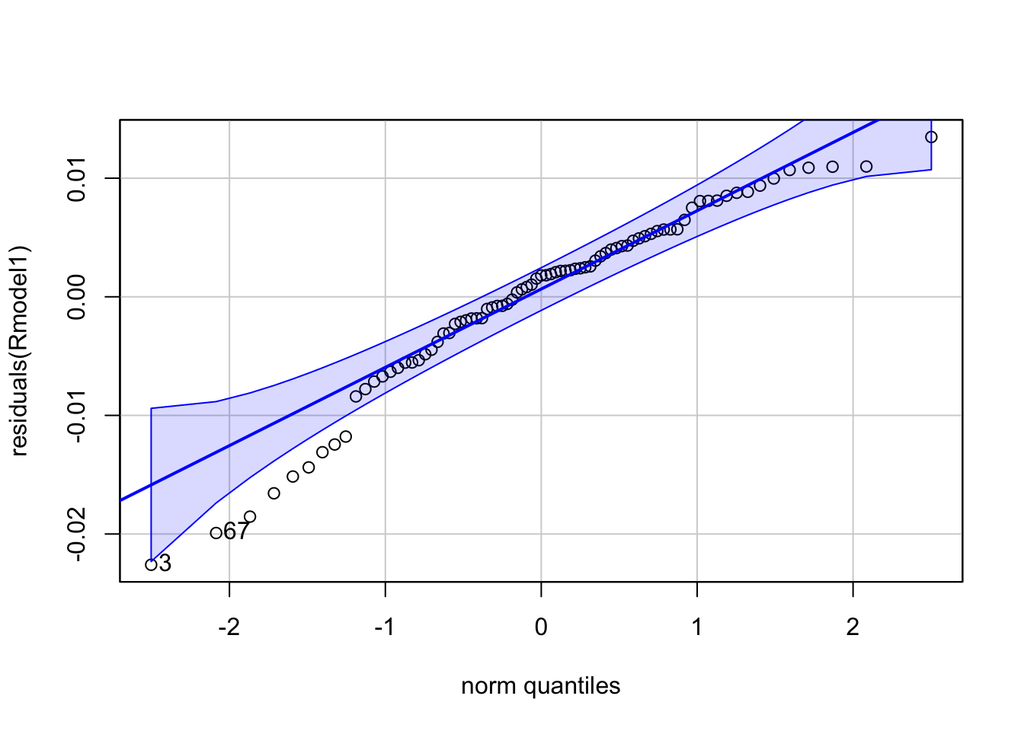

```
## [1]  3 67
```

```r
qqPlot(residuals(Rmodel1))
```

```r
leveneTest(residuals(Rmodel1)~Treatment*Temperature, data=PRdata)
```

```
## Levene's Test for Homogeneity of Variance (center = median)
##       Df F value Pr(>F)
## group  3  1.2153 0.3099
##       77
```

Conduct post hoc test.

```r
emm<-emmeans(Rmodel1, ~Treatment*Temperature)
cld(emm)
```

```
##  Treatment Temperature  emmean      SE   df lower.CL upper.CL .group
##  Ambient   30          -0.0232 0.00324 3.26  -0.0331 -0.01338  1
##  High      30          -0.0209 0.00319 3.07  -0.0309 -0.01089  1
##  High      27          -0.0206 0.00321 3.16  -0.0306 -0.01072  1
##  Ambient   27          -0.0182 0.00330 3.50  -0.0279 -0.00852  1
##
## Degrees-of-freedom method: kenward-roger
## Confidence level used: 0.95
## P value adjustment: tukey method for comparing a family of 4 estimates
## significance level used: alpha = 0.05
## NOTE: Compact letter displays can be misleading
##       because they show NON-findings rather than findings.
##       Consider using 'pairs()', 'pwpp()', or 'pwpm()' instead.
```

## Net Photosynthesis

Build linear mixed effect model and examine for Photosynthesis

```r
Pmodel1<-lmer(P.nmol.org.min~Treatment*Temperature + (1|Run) + (1|Tank), data=PRdata) #run nested within day
anova(Pmodel1, type="II")
```

```
## Type II Analysis of Variance Table with Satterthwaite's method
##                           Sum Sq    Mean Sq NumDF  DenDF F value Pr(>F)
## Treatment             6.1685e-05 6.1685e-05     1  9.891  1.5907 0.2362
## Temperature           5.5754e-05 5.5754e-05     1 67.344  1.4378 0.2347
## Treatment:Temperature 2.3068e-05 2.3068e-05     1 67.350  0.5949 0.4432
```

```r
summary(Pmodel1)
```

```
## Linear mixed model fit by REML. t-tests use Satterthwaite's method [
## lmerModLmerTest]
## Formula: P.nmol.org.min ~ Treatment * Temperature + (1 | Run) + (1 | Tank)
##    Data: PRdata
##
## REML criterion at convergence: -541.9
##
## Scaled residuals:
##      Min       1Q   Median       3Q      Max
## -1.67206 -0.73425 -0.05761  0.66440  2.62189
##
## Random effects:
##  Groups   Name        Variance  Std.Dev.
##  Tank     (Intercept) 9.765e-06 0.003125
##  Run      (Intercept) 0.000e+00 0.000000
##  Residual             3.878e-05 0.006227
## Number of obs: 81, groups:  Tank, 12; Run, 4
##
## Fixed effects:
##                              Estimate Std. Error        df t value Pr(>|t|)
## (Intercept)                  0.018057   0.001958 20.300528   9.224 1.06e-08 ***
## TreatmentHigh                0.004006   0.002710 18.825701   1.479    0.156
## Temperature30                0.002801   0.002026 67.396240   1.383    0.171
## TreatmentHigh:Temperature30 -0.002143   0.002779 67.350076  -0.771    0.443
## ---
## Signif. codes:  0 '***' 0.001 '**' 0.01 '*' 0.05 '.' 0.1 ' ' 1
##
## Correlation of Fixed Effects:
##             (Intr) TrtmnH Tmpr30
## TreatmntHgh -0.723
## Temperatr30 -0.544  0.393
## TrtmntH:T30  0.396 -0.532 -0.729
## optimizer (nloptwrap) convergence code: 0 (OK)
## boundary (singular) fit: see help('isSingular')
```

Run only as regular ANOVA.

```r
summary(aov(P.nmol.org.min~Treatment*Temperature, data=PRdata))
```

```
##                       Df   Sum Sq   Mean Sq F value Pr(>F)
## Treatment              1 0.000219 2.186e-04   4.626 0.0346 *
## Temperature            1 0.000058 5.802e-05   1.228 0.2712
## Treatment:Temperature  1 0.000030 2.951e-05   0.625 0.4318
## Residuals             77 0.003638 4.725e-05
## ---
## Signif. codes:  0 '***' 0.001 '**' 0.01 '*' 0.05 '.' 0.1 ' ' 1
```

In this analysis, treatment is significant.

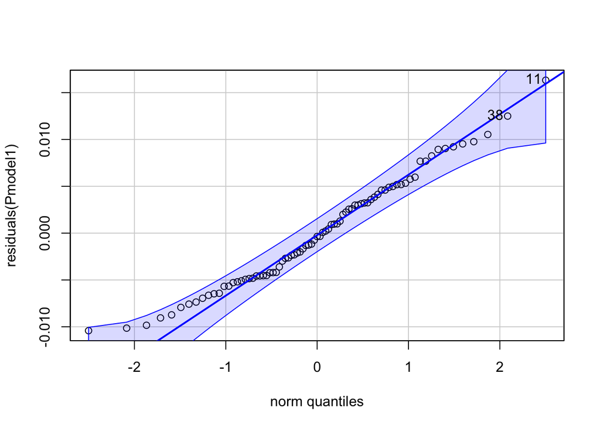

```
## [1] 11 38
```

```r
qqPlot(residuals(Pmodel1))
```

```r
leveneTest(residuals(Pmodel1)~Treatment*Temperature, data=PRdata)
```

```
## Levene's Test for Homogeneity of Variance (center = median)
##       Df F value Pr(>F)
## group  3  0.3712  0.774
##       77
```

Conduct post hoc test.

```r
emm<-emmeans(Pmodel1, ~Treatment*Temperature)
cld(emm)
```

```
##  Treatment Temperature emmean      SE   df lower.CL upper.CL .group
##  Ambient   27          0.0181 0.00197 12.4   0.0138   0.0223  1
##  Ambient   30          0.0209 0.00191 11.2   0.0167   0.0251  1
##  High      27          0.0221 0.00188 10.6   0.0179   0.0262  1
##  High      30          0.0227 0.00185 10.1   0.0186   0.0268  1
##
## Degrees-of-freedom method: kenward-roger
## Confidence level used: 0.95
## P value adjustment: tukey method for comparing a family of 4 estimates
## significance level used: alpha = 0.05
## NOTE: Compact letter displays can be misleading
##       because they show NON-findings rather than findings.
##       Consider using 'pairs()', 'pwpp()', or 'pwpm()' instead.
```

## Gross Photosynthesis

Build linear mixed effect model and examine for GP

```r
GPmodel1<-lmer(GP.nmol.org.min~Treatment*Temperature + (1|Run) + (1|Tank), data=PRdata) #run nested within day
anova(GPmodel1, type="II")
```

```
## Type II Analysis of Variance Table with Satterthwaite's method
##                          Sum Sq   Mean Sq NumDF  DenDF F value Pr(>F)
## Treatment             4.799e-05 4.799e-05     1  9.993  0.3795 0.5516
## Temperature           1.200e-04 1.200e-04     1  2.049  0.9490 0.4306
## Treatment:Temperature 2.331e-04 2.331e-04     1 65.740  1.8434 0.1792
```

```r
summary(GPmodel1)
```

```
## Linear mixed model fit by REML. t-tests use Satterthwaite's method [
## lmerModLmerTest]
## Formula: GP.nmol.org.min ~ Treatment * Temperature + (1 | Run) + (1 |
##     Tank)
##    Data: PRdata
##
## REML criterion at convergence: -449.1
##
## Scaled residuals:
##      Min       1Q   Median       3Q      Max
## -1.95328 -0.57777  0.00067  0.41042  2.78514
##
## Random effects:
##  Groups   Name        Variance  Std.Dev.
##  Tank     (Intercept) 2.988e-05 0.005466
##  Run      (Intercept) 1.190e-05 0.003449
##  Residual             1.264e-04 0.011245
## Number of obs: 81, groups:  Tank, 12; Run, 4
##
## Fixed effects:
##                              Estimate Std. Error        df t value Pr(>|t|)
## (Intercept)                  0.036543   0.004259  6.991507   8.580 5.86e-05 ***
## TreatmentHigh                0.006046   0.004830 19.429504   1.252    0.226
## Temperature30                0.007777   0.005031  3.948584   1.546    0.198
## TreatmentHigh:Temperature30 -0.006821   0.005024 65.740346  -1.358    0.179
## ---
## Signif. codes:  0 '***' 0.001 '**' 0.01 '*' 0.05 '.' 0.1 ' ' 1
##
## Correlation of Fixed Effects:
##             (Intr) TrtmnH Tmpr30
## TreatmntHgh -0.593
## Temperatr30 -0.607  0.291
## TrtmntH:T30  0.330 -0.541 -0.531
```

Run only as regular ANOVA.

```r
summary(aov(GP.nmol.org.min~Treatment*Temperature, data=PRdata))
```

```
##                       Df   Sum Sq   Mean Sq F value Pr(>F)
## Treatment              1 0.000237 0.0002368   1.489  0.226
## Temperature            1 0.000348 0.0003479   2.188  0.143
## Treatment:Temperature  1 0.000258 0.0002579   1.622  0.207
## Residuals             77 0.012245 0.0001590
```

Same results.

Check assumptions of model for residual normality and variance. Passes.

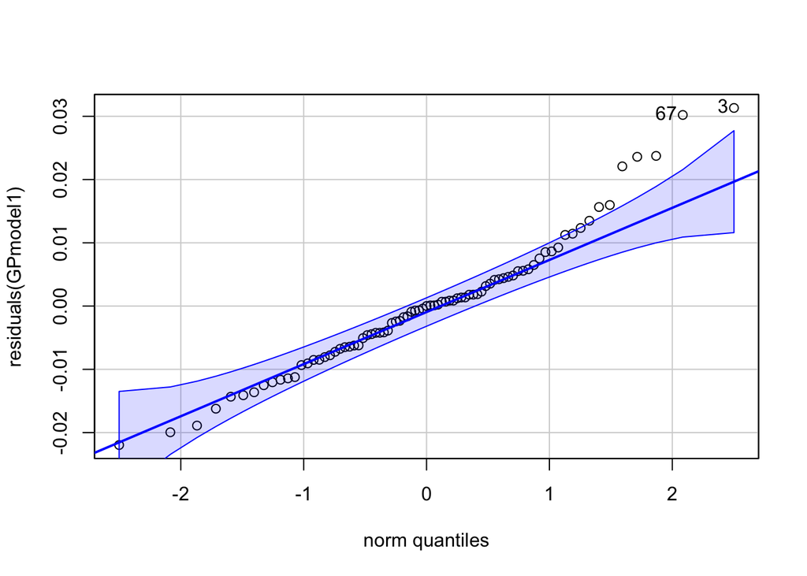

```
## [1]  3 67
```

```r
qqPlot(residuals(GPmodel1))
```

```r
leveneTest(residuals(GPmodel1)~Treatment*Temperature, data=PRdata)
```

```
## Levene's Test for Homogeneity of Variance (center = median)
##       Df F value Pr(>F)
## group  3  0.2467 0.8634
##       77
```

Conduct post hoc test.

```r
emm<-emmeans(GPmodel1, ~Treatment*Temperature)
cld(emm)
```

```
##  Treatment Temperature emmean      SE   df lower.CL upper.CL .group
##  Ambient   27          0.0365 0.00427 6.80   0.0264   0.0467  1
##  High      27          0.0426 0.00414 6.04   0.0325   0.0527  1
##  High      30          0.0435 0.00410 5.84   0.0334   0.0536  1
##  Ambient   30          0.0443 0.00418 6.29   0.0342   0.0544  1
##
## Degrees-of-freedom method: kenward-roger
## Confidence level used: 0.95
## P value adjustment: tukey method for comparing a family of 4 estimates
## significance level used: alpha = 0.05
## NOTE: Compact letter displays can be misleading
##       because they show NON-findings rather than findings.
##       Consider using 'pairs()', 'pwpp()', or 'pwpm()' instead.
```

## P:R

Build linear mixed effect model and examine for PR ratio

```r
PRmodel1<-lmer(ratio~Treatment*Temperature + (1|Run) + (1|Tank), data=PRdata) #run as random
anova(PRmodel1, type="II")
```

```
## Type II Analysis of Variance Table with Satterthwaite's method
##                        Sum Sq Mean Sq NumDF  DenDF F value Pr(>F)
## Treatment             0.73051 0.73051     1  7.076  3.3358 0.1101
## Temperature           0.01944 0.01944     1  2.025  0.0888 0.7936
## Treatment:Temperature 0.12040 0.12040     1 62.772  0.5498 0.4612
```

```r
summary(PRmodel1)
```

```
## Linear mixed model fit by REML. t-tests use Satterthwaite's method [
## lmerModLmerTest]
## Formula: ratio ~ Treatment * Temperature + (1 | Run) + (1 | Tank)
##    Data: PRdata
##
## REML criterion at convergence: 119
##
## Scaled residuals:
##      Min       1Q   Median       3Q      Max
## -1.92190 -0.73625 -0.06253  0.51970  2.68249
##
## Random effects:
##  Groups   Name        Variance Std.Dev.
##  Tank     (Intercept) 0.008975 0.09474
##  Run      (Intercept) 0.037827 0.19449
##  Residual             0.218991 0.46796
## Number of obs: 81, groups:  Tank, 12; Run, 4
##
## Fixed effects:
##                             Estimate Std. Error      df t value Pr(>|t|)
## (Intercept)                   2.0212     0.1809  3.5566  11.174 0.000677 ***
## TreatmentHigh                 0.1358     0.1608 23.6192   0.844 0.406882
## Temperature30                -0.0166     0.2470  3.1752  -0.067 0.950434
## TreatmentHigh:Temperature30   0.1549     0.2089 62.7723   0.741 0.461159
## ---
## Signif. codes:  0 '***' 0.001 '**' 0.01 '*' 0.05 '.' 0.1 ' ' 1
##
## Correlation of Fixed Effects:
##             (Intr) TrtmnH Tmpr30
## TreatmntHgh -0.476
## Temperatr30 -0.697  0.309
## TrtmntH:T30  0.324 -0.677 -0.450
```

Run only as regular ANOVA.

```r
summary(aov(ratio~Treatment*Temperature, data=PRdata))
```

```
##                       Df Sum Sq Mean Sq F value Pr(>F)
## Treatment              1  0.973  0.9727   3.943 0.0506 .
## Temperature            1  0.094  0.0936   0.380 0.5396
## Treatment:Temperature  1  0.101  0.1008   0.409 0.5246
## Residuals             77 18.994  0.2467
## ---
## Signif. codes:  0 '***' 0.001 '**' 0.01 '*' 0.05 '.' 0.1 ' ' 1
```

Same results.

Check assumptions of model for residual normality and variance. Meets assumptions.

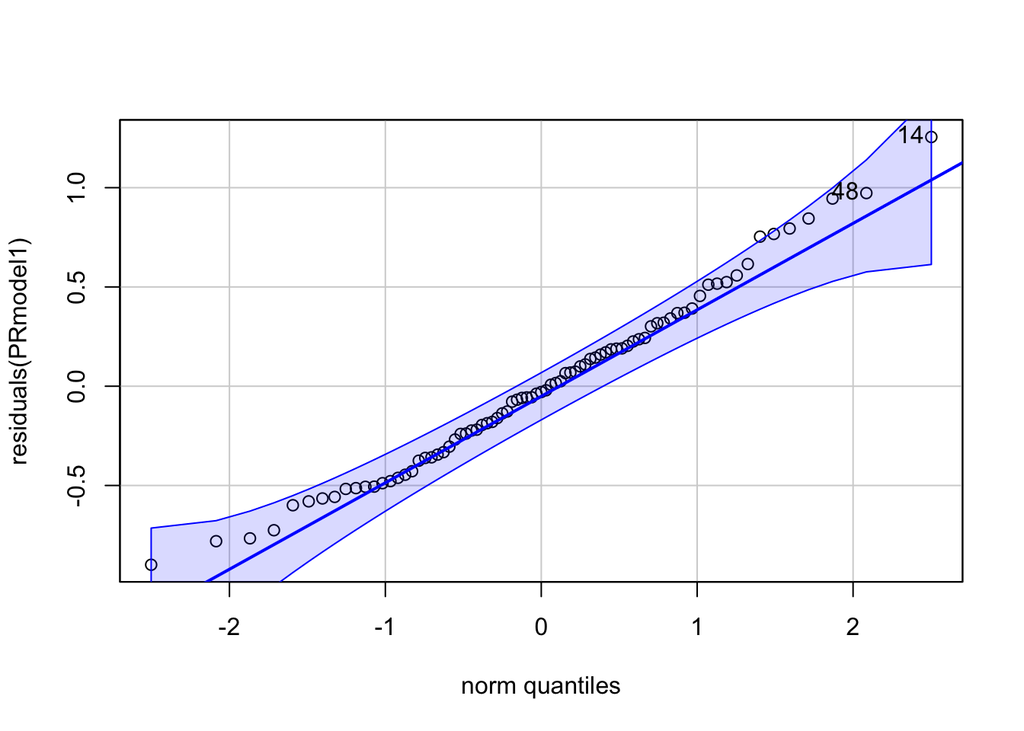

```
## [1] 14 48
```

```r
qqPlot(residuals(PRmodel1))
```

```r
leveneTest(residuals(PRmodel1)~Treatment*Temperature, data=PRdata)
```

```
## Levene's Test for Homogeneity of Variance (center = median)
##       Df F value Pr(>F)
## group  3   1.709 0.1721
##       77
```

Conduct post hoc test.

```r
emm<-emmeans(PRmodel1, ~Treatment*Temperature)
cld(emm)
```

```
##  Treatment Temperature emmean    SE   df lower.CL upper.CL .group
##  Ambient   30            2.00 0.178 3.28     1.47     2.54  1
##  Ambient   27            2.02 0.181 3.54     1.49     2.55  1
##  High      27            2.16 0.176 3.17     1.61     2.70  1
##  High      30            2.30 0.175 3.07     1.75     2.84  1
##
## Degrees-of-freedom method: kenward-roger
## Confidence level used: 0.95
## P value adjustment: tukey method for comparing a family of 4 estimates
## significance level used: alpha = 0.05
## NOTE: Compact letter displays can be misleading
##       because they show NON-findings rather than findings.
##       Consider using 'pairs()', 'pwpp()', or 'pwpm()' instead.
```

### Generate summary tables of mean and SE for all variables

Generate summary of all respiration data.

```r
summary<-PRdata%>%
  group_by(Temperature, Treatment)%>%
  summarise(N=length(R.nmol.org.min),
            Mean_R=mean(R.nmol.org.min),
            SE_R=sd(R.nmol.org.min)/sqrt(length(R.nmol.org.min)),
            Mean_P=mean(P.nmol.org.min),
            SE_P=sd(P.nmol.org.min)/sqrt(length(P.nmol.org.min)),
            Mean_GP=mean(GP.nmol.org.min),
            SE_GP=sd(GP.nmol.org.min)/sqrt(length(GP.nmol.org.min)),
            Mean_PR=mean(ratio),
            SE_PR=sd(ratio)/sqrt(length(ratio)))

summary%>%
  write_csv(., "Mcap2021/Output/Respiration/mean_respiration.csv")
```